# AttritionEDACaseStudy2DDS

Fidel

8/4/2021

Intro: Good afternoon Mr. Steven Miller and Mr. Justin Mitchel. I received your inquiry about determining the top 3 factors influencing attrition. In our EDA we were able to identify Age, Monthly Salary and OverTime our of 35 variables as the major influences on attrition. We also evaluated gender at each step to ensure gender discrimination was not occurring in the organization and we are happy to report we did not find any evidence. We assess the top 3 variables are related and would assess there are generational conflicts in the organizations. We found great discrepancies in pay between departments and ages, A right skewed histogram of ages throughout the company, the highest age occurence being left of the overall average age. The the range in ages is about 42 years which is about 4 generations. This is assessing generations as 20 years, each overlapping by 10 years. The overall satisfaction in the job, relationships and environment are consistent with each other and may indicate something greater not measured is influencing the attrition.

GitHub Repo: https://github.com/fideltamares/CaseStudy2DDS GitHub Website: https://fideltamares.github.io/ Fidel Tamares Youtube: https://www.youtube.com/watch?v=uXAGDhGvZ7A

Code Chuck #1: Initial setup by Loading packages, importing data, checking for missing data and veryifing the dataframe charactistics

```r
#Packages used in this EDA

library(ggplot2)
library(tidyverse)
library(dplyr)
library(GGally)
library(corrplot)
library(cowplot)
library(scales)
library(Hmisc)
library(magrittr)
library(class)
library(caret)
#Importing data files and establishing dataframes
C2Data = read.csv(file.choose(),header = TRUE)
C2DataNoAtr = read.csv(file.choose(),header = TRUE)
C2DataNoSalary = read.csv(file.choose(),header = TRUE)
#Checking dataframe breakdowns
str(C2Data)
```

```
## 'data.frame':    870 obs. of  36 variables:
##  $ ID                      : int  1 2 3 4 5 6 7 8 9 10 ...
##  $ Age                     : int  32 40 35 32 24 27 41 37 34 34 ...
##  $ Attrition               : chr  "No" "No" "No" "No" ...
##  $ BusinessTravel          : chr  "Travel_Rarely" "Travel_Rarely" "Travel_Frequently" "Travel_Rarely" ...
##  $ DailyRate               : int  117 1308 200 801 567 294 1283 309 1333 653 ...
##  $ Department              : chr  "Sales" "Research & Development" "Research & Development" "Sales" ...
##  $ DistanceFromHome        : int  13 14 18 1 2 10 5 10 10 10 ...
##  $ Education               : int  4 3 2 4 1 2 5 4 4 4 ...
##  $ EducationField          : chr  "Life Sciences" "Medical" "Life Sciences" "Marketing" ...
##  $ EmployeeCount           : int  1 1 1 1 1 1 1 1 1 1 ...
##  $ EmployeeNumber          : int  859 1128 1412 2016 1646 733 1448 1105 1055 1597 ...
##  $ EnvironmentSatisfaction : int  2 3 3 3 1 4 2 4 3 4 ...
##  $ Gender                  : chr  "Male" "Male" "Male" "Female" ...
##  $ HourlyRate              : int  73 44 60 48 32 32 90 88 87 92 ...
```

[output cut: 22 more lines]

```r
#Checking for NA/missing Data, there is no missing data
colSums(is.na(C2Data))
```

```
##                       ID                      Age                Attrition
##                        0                        0                        0
##           BusinessTravel                DailyRate               Department
##                        0                        0                        0
##         DistanceFromHome                Education           EducationField
##                        0                        0                        0
##            EmployeeCount           EmployeeNumber  EnvironmentSatisfaction
##                        0                        0                        0
##                   Gender               HourlyRate           JobInvolvement
##                        0                        0                        0
##                 JobLevel                  JobRole          JobSatisfaction
##                        0                        0                        0
##            MaritalStatus            MonthlyIncome              MonthlyRate
##                        0                        0                        0
##       NumCompaniesWorked                   Over18                 OverTime
##                        0                        0                        0
##        PercentSalaryHike        PerformanceRating RelationshipSatisfaction
##                        0                        0                        0
##            StandardHours         StockOptionLevel        TotalWorkingYears
##                        0                        0                        0
##    TrainingTimesLastYear          WorkLifeBalance           YearsAtCompany
##                        0                        0                        0
##       YearsInCurrentRole  YearsSinceLastPromotion     YearsWithCurrManager
##                        0                        0                        0
```

```r
colSums(is.na(C2DataNoAtr))
```

```
##                       ID                      Age           BusinessTravel
##                        0                        0                        0
##                DailyRate               Department         DistanceFromHome
##                        0                        0                        0
##                Education           EducationField            EmployeeCount
##                        0                        0                        0
##           EmployeeNumber  EnvironmentSatisfaction                   Gender
##                        0                        0                        0
##               HourlyRate           JobInvolvement                 JobLevel
##                        0                        0                        0
##                  JobRole          JobSatisfaction            MaritalStatus
##                        0                        0                        0
##            MonthlyIncome              MonthlyRate       NumCompaniesWorked
##                        0                        0                        0
##                   Over18                 OverTime        PercentSalaryHike
##                        0                        0                        0
##        PerformanceRating RelationshipSatisfaction            StandardHours
##                        0                        0                        0
##         StockOptionLevel        TotalWorkingYears    TrainingTimesLastYear
##                        0                        0                        0
##          WorkLifeBalance           YearsAtCompany       YearsInCurrentRole
##                        0                        0                        0
##  YearsSinceLastPromotion     YearsWithCurrManager
##                        0                        0
```

```r
colSums(is.na(C2DataNoSalary))
```

```
## PK...
##     0
```

```r
#Convert char vars into factors
C2Data[sapply(C2Data, is.character)] <- lapply(C2Data[sapply(C2Data, is.character)], as.factor)
```

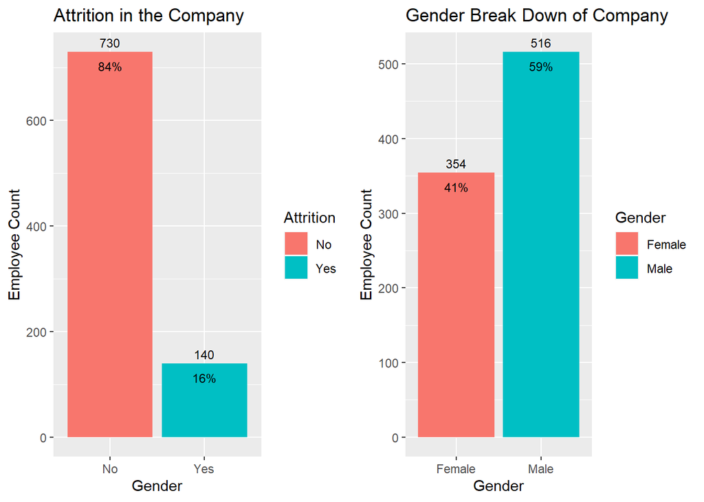

```r
#Starting with overall attrition (count/ratio)
ZAtr <- C2Data %>%
  select(Attrition) %>%
  ggplot(aes(x=Attrition, fill=Attrition)) +
  geom_bar(stat="count") +
  geom_text(aes(label = ..count..), stat = "count",position = "stack",vjust= -.5, size=3) +
  geom_text(aes(label = scales::percent((..count..)/sum(..count..))),stat = "count",position = "stack",vjust= 2, size=3) +
  labs(x="Gender",y="Employee Count", title="Attrition in the Company")

#company breakdown by gender (count/ratio), 354 (41%) female and 516 (59%) male, 870 total
ZCompanyGender <- C2Data %>%
  select(Gender) %>%
  ggplot(aes(x=Gender, fill=Gender)) +
  geom_bar(stat="count") +
  geom_text(aes(label = ..count..), stat = "count",position = "stack",vjust= -.5, size=3) +
  geom_text(aes(label = scales::percent((..count..)/sum(..count..))),stat = "count",position = "stack",vjust= 2, size=3) +
  labs(x="Gender",y="Employee Count", title="Gender Break Down of Company")

# departments (3), 35 (4%) in HR, 562 (65%) in RD and 273 (31%) in Sales
ZCompanyDeptEmployees <- C2Data %>%
  select(Department) %>%
  ggplot(aes(x=Department, fill=Department))+
  geom_bar(stat="count") +
  geom_text(aes(label = ..count..), stat = "count",position = "stack",vjust= -.5,size=3) +
  geom_text(aes(label = scales::percent((..count..)/sum(..count..))),stat = "count",position = "stack",vjust= 1.5, size=3) +
  labs(x="Department",y="Employee Count", title="Number of Employees in each department")

#all department breakdown
plot_grid(ZAtr, ZCompanyGender,nrow=1)
```

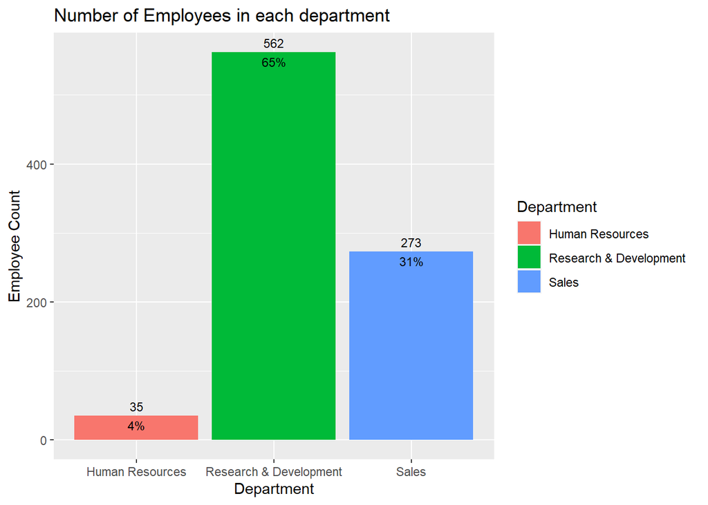

```r
plot_grid(ZCompanyDeptEmployees,nrow=1)
```

Code Chunk 3: Overall Attrition check, By Department, Job Titles and Income. Each chart has an interesting point that requires further analysis. Right skewed age with highest frequency left of the mean, HR lowest paid of all who quit and sales has the largest porportion of attrition. Withi this knowledge we can create a plan as follows:

1. Age Analysis
2. Income analysis
3. Job Satistication
4. Environmental Satisfaction

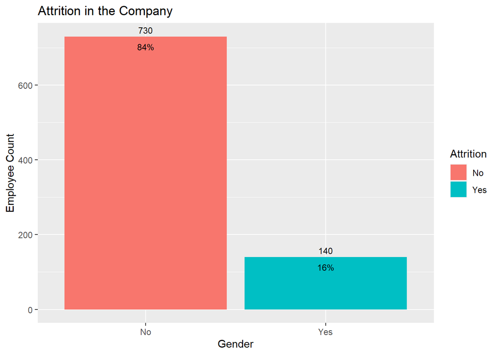

```r
#Overall Attrition, from first section
ZAtr <- C2Data %>%
  select(Attrition) %>%
  ggplot(aes(x=Attrition, fill=Attrition)) +
  geom_bar(stat="count") +
  geom_text(aes(label = ..count..), stat = "count",position = "stack",vjust= -.5, size=3) +
  geom_text(aes(label = scales::percent((..count..)/sum(..count..))),stat = "count",position = "stack",vjust= 2, size=3) +
  labs(x="Gender",y="Employee Count", title="Attrition in the Company")

#Attrition by Job
ArtJobRole<- C2Data %>%
  select(JobRole, Attrition) %>%
  ggplot(aes(x=JobRole, fill=Attrition))+
  geom_bar(position="dodge",stat="count") +
  labs(x="Job Roles",y="Employee Count", title="Attrition by Job Title")+
  theme(axis.text.x = element_text(angle = 90, hjust = 1, vjust = 0.5))

#Attrition by age

AgeFemAtr <- C2Data %>%
  select(Gender, Age, Attrition) %>%
  filter(Gender == "Female", Attrition =="Yes") %>%
  ggplot(aes(x=Age)) +
  geom_density(alpha = .5, fill='pink') +
  geom_vline(aes(xintercept=mean(Age)), color='red') +
  geom_hline(aes(yintercept=0)) +
  labs(x="Ages",y="Density", title="Ages for Females Who Quit") +
  annotate("text", label = "Mean = 33.83", x=50, y=.04, color = "black")

AgeMalAtr <- C2Data %>%
  select(Gender, Age, Attrition) %>%
  filter(Gender == "Male", Attrition =="Yes") %>%
  ggplot(aes(x=Age)) +
  geom_density(alpha = .5, fill='Light Blue') +
  geom_vline(aes(xintercept=mean(Age)), color='red') +
  geom_hline(aes(yintercept=0)) +
  labs(x="Ages",y="Density", title="Ages for Males Who Quit") +
  annotate("text", label = "Mean = 33.76", x=50, y=.04, color = "black")


#Attrition by income

IncDeptAtr <- C2Data %>% select(Department, MonthlyIncome, Attrition) %>% group_by(Attrition, Department) %>%
  summarise(IncDeptAtr=mean(MonthlyIncome)) %>%
  ggplot(aes(x=reorder(Department, IncDeptAtr), y=IncDeptAtr, fill=Attrition)) +
  geom_bar(stat="identity", position="dodge") + facet_wrap(~Attrition) +
  labs(y="Average Income", x="Average Monthly Income", title="Average Income by Department and Attrition Status")
ZAtr
```

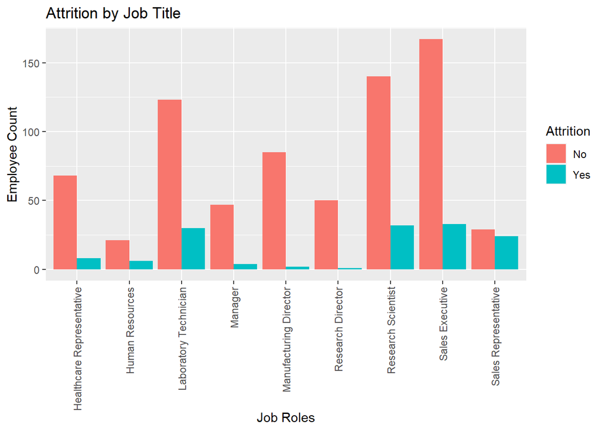

```r
ArtJobRole
```

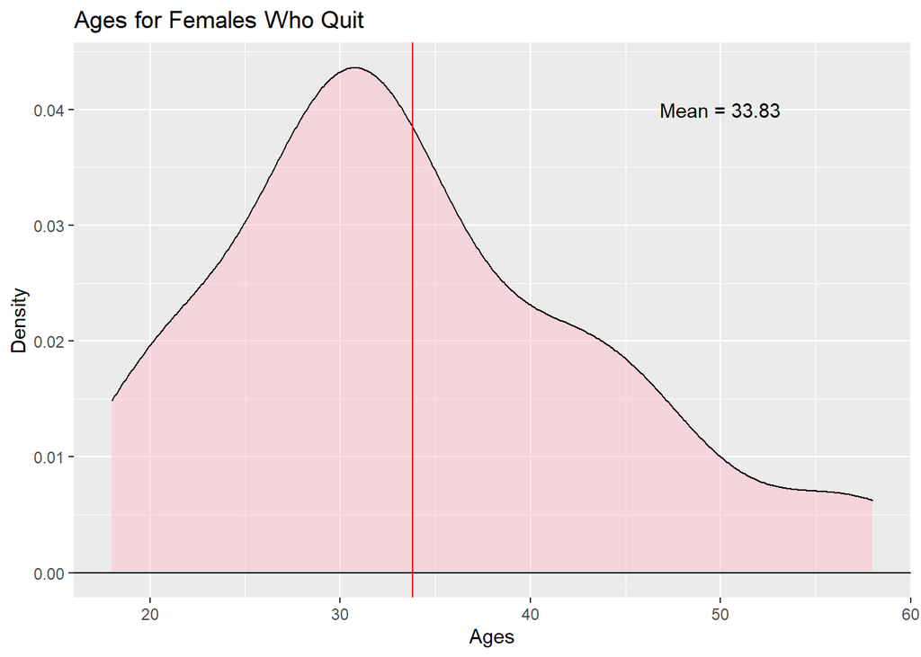

```r
AgeFemAtr
```

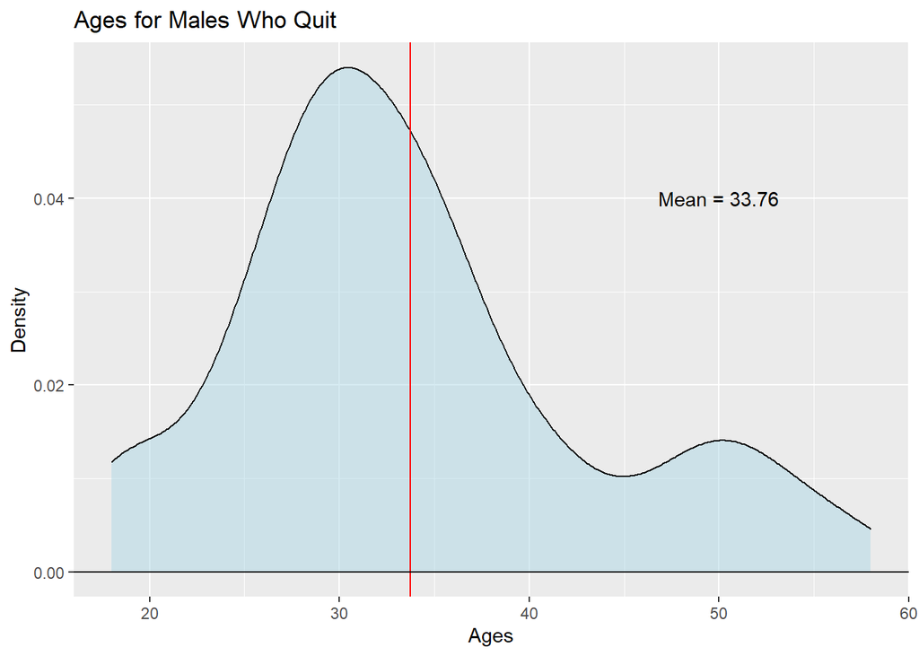

```r
AgeMalAtr
```

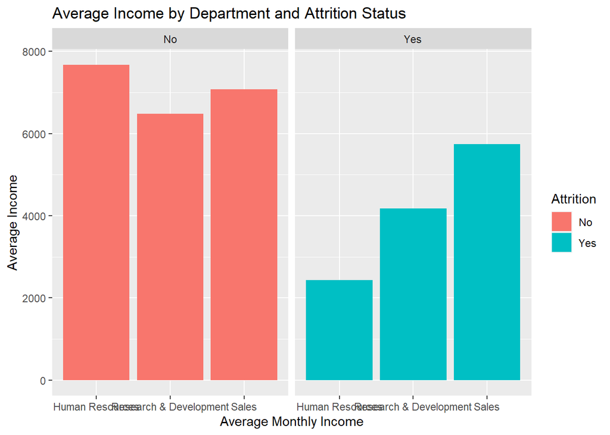

```r
IncDeptAtr
```

Code Chunk 4: Age Breakdown by department and gender

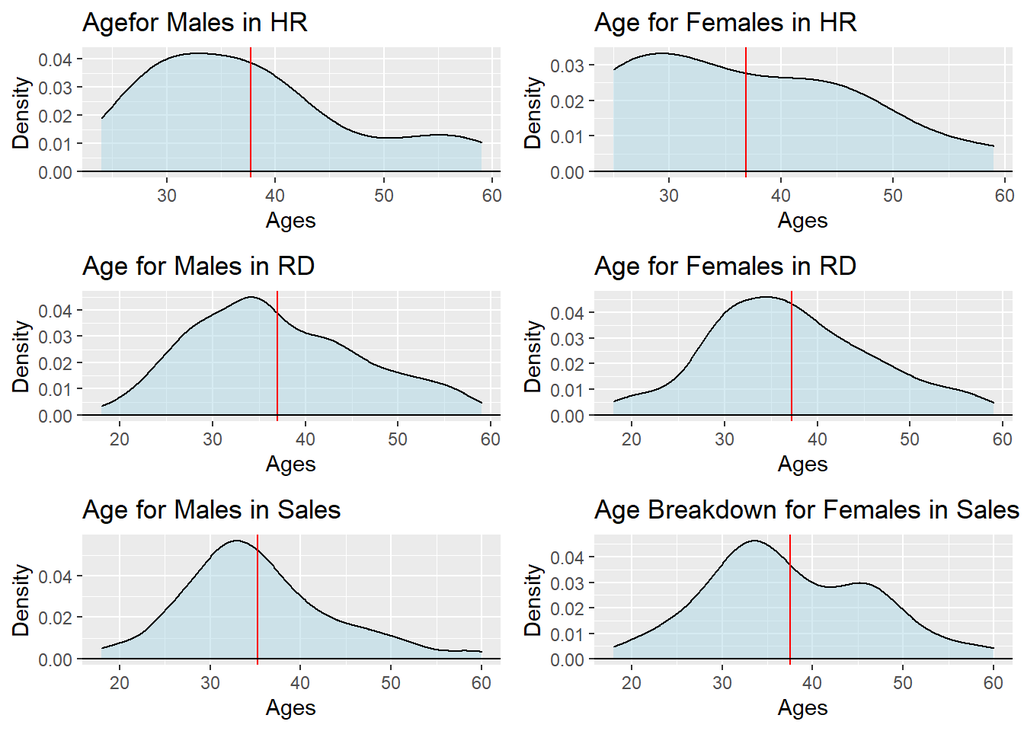

```r
#Age Breakdown for Employees per Dept

AgeDeptHRMaleATR <- C2Data %>%
  select(Gender, Age, Department, Attrition) %>%
  filter(Gender == "Male", Department=="Human Resources") %>%
  ggplot(aes(x=Age)) +
  geom_density(alpha = .5, fill='Light Blue') +
  geom_vline(aes(xintercept=mean(Age)), color='red')+
  geom_hline(aes(yintercept=0)) +
  labs(x="Ages",y="Density", title="Agefor Males in HR")

AgeDeptHRFemATR <- C2Data %>%
  select(Gender, Age, Department, Attrition) %>%
  filter(Gender == "Female", Department=="Human Resources") %>%
  ggplot(aes(x=Age)) +
  geom_density(alpha = .5, fill='Light Blue') +
  geom_vline(aes(xintercept=mean(Age)), color='red')+
  geom_hline(aes(yintercept=0)) +
  labs(x="Ages",y="Density", title="Age for Females in HR")

AgeDeptRDMaleATR <- C2Data %>%
  select(Gender, Age, Department, Attrition) %>%
  filter(Gender == "Male", Department=="Research & Development") %>%
  ggplot(aes(x=Age)) +
  geom_density(alpha = .5, fill='Light Blue') +
  geom_vline(aes(xintercept=mean(Age)), color='red')+
  geom_hline(aes(yintercept=0)) +
  labs(x="Ages",y="Density", title="Age for Males in RD")

AgeDeptRDFemATR <- C2Data %>%
  select(Gender, Age, Department, Attrition) %>%
  filter(Gender == "Female", Department=="Research & Development") %>%
  ggplot(aes(x=Age)) +
  geom_density(alpha = .5, fill='Light Blue') +
  geom_vline(aes(xintercept=mean(Age)), color='red')+
  geom_hline(aes(yintercept=0)) +
  labs(x="Ages",y="Density", title="Age for Females in RD")

AgeDeptSalHRMaleATR<- C2Data %>%
  select(Gender, Age, Department, Attrition) %>%
  filter(Gender == "Male", Department=="Sales") %>%
  ggplot(aes(x=Age)) +
  geom_density(alpha = .5, fill='Light Blue') +
  geom_vline(aes(xintercept=mean(Age)), color='red')+
  geom_hline(aes(yintercept=0)) +
  labs(x="Ages",y="Density", title="Age for Males in Sales")

AgeDeptSalRFemATR <- C2Data %>%
  select(Gender, Age, Department, Attrition) %>%
  filter(Gender == "Female", Department=="Sales") %>%
  ggplot(aes(x=Age)) +
  geom_density(alpha = .5, fill='Light Blue') +
  geom_vline(aes(xintercept=mean(Age)), color='red')+
  geom_hline(aes(yintercept=0)) +
  labs(x="Ages",y="Density", title="Age Breakdown for Females in Sales")

plot_grid(AgeDeptHRMaleATR,AgeDeptHRFemATR, AgeDeptRDMaleATR, AgeDeptRDFemATR, AgeDeptSalHRMaleATR,AgeDeptSalRFemATR, nrow = 3)
```

Code Chunk 4a: Age Analysis age distribution between genders, this suggests age is a factor in determing if someone is at risk of attrtion. This may be part of generational mindsets as these ages span almost 3 different generations. We followed this up with totalworking years. We chose total working years as it captures timeoutside the company too and is more related to generational workforces than time in the company.

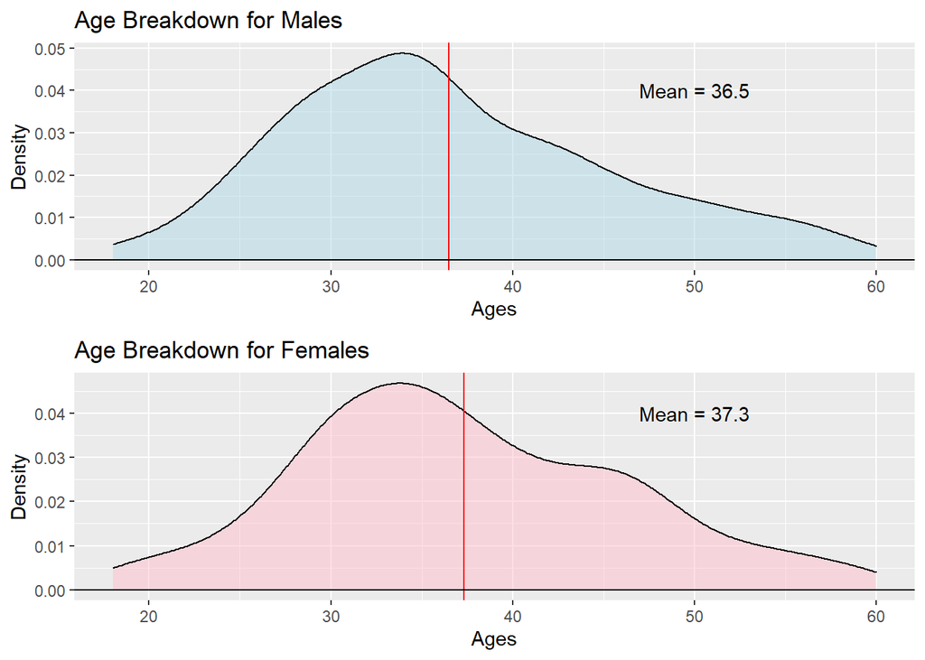

```r
# Male age distribution
AgeMaleDist <- C2Data %>%
  select(Gender, Age) %>%
  filter(Gender == "Male") %>%
  ggplot(aes(x=Age)) +
  geom_density(alpha = .5, fill='Light Blue') +
  geom_vline(aes(xintercept=mean(Age)), color='red') +
  geom_hline(aes(yintercept=0)) +
  labs(x="Ages",y="Density", title="Age Breakdown for Males") +
  annotate("text", label = "Mean = 36.5" , x=50, y=.04, color = "black")

# Female age distribution
AgeFemaleDist <- C2Data %>%
  select(Gender, Age) %>%
  filter(Gender == "Female") %>%
  ggplot(aes(x=Age)) +
  geom_density(alpha = .5, fill='Pink') +
  geom_vline(aes(xintercept=mean(Age)), color='red')+
  geom_hline(aes(yintercept=0)) +
  labs(x="Ages",y="Density", title="Age Breakdown for Females") +
  annotate("text", label = "Mean = 37.3", x=50, y=.04, color = "black")



# Female age distribution
AgeFemaleTWY <- C2Data %>%
  select(Gender, TotalWorkingYears, Age) %>%
  filter(Gender == "Female") %>%
  ggplot(aes(x=TotalWorkingYears)) +
  geom_density(alpha = .5, fill='Pink') +
  geom_vline(aes(xintercept=mean(Age)), color='red')+
  geom_hline(aes(yintercept=0)) +
  labs(x="Years",y="Density", title="Total Years Works for Females") +
  annotate("text", label = "Mean = 37.3", x=25, y=.04, color = "black")

# Male age distribution
AgeMaleTWY <- C2Data %>%
  select(Gender, TotalWorkingYears, Age) %>%
  filter(Gender == "Male") %>%
  ggplot(aes(x=TotalWorkingYears)) +
  geom_density(alpha = .5, fill='Light Blue') +
  geom_vline(aes(xintercept=mean(Age)), color='red')+
  geom_hline(aes(yintercept=0)) +
  labs(x="Years",y="Density", title="Total Years Works for Males") +
  annotate("text", label = "Mean = 36.5", x=25, y=.04, color = "black")

#all department breakdown
plot_grid(AgeMaleDist, AgeFemaleDist, nrow=2)
```

[figure not shown]

```r
plot_grid(AgeMaleTWY, AgeFemaleTWY, nrow=2)
```

Code Chunk 4b: Gender attrition break down with age distribution, further supporting analysis for ages impacting attrition.

```r
#attrition by ages and female

AgeFemAtr1 <- C2Data %>% # Average Female Age who Quit = 33.83
  select(Gender, Age, Attrition) %>%
  filter (Gender == "Female", Attrition == "Yes")

mean(AgeFemAtr1$Age)
```

```
## [1] 33.83019
```

```r
AgeFemNAtr1 <- C2Data %>% # Average Female Age who Did not Quit = 37.91
  select(Gender, Age, Attrition) %>%
  filter (Gender == "Female", Attrition == "No")

mean(AgeFemNAtr1$Age)
```

```
## [1] 37.91694
```

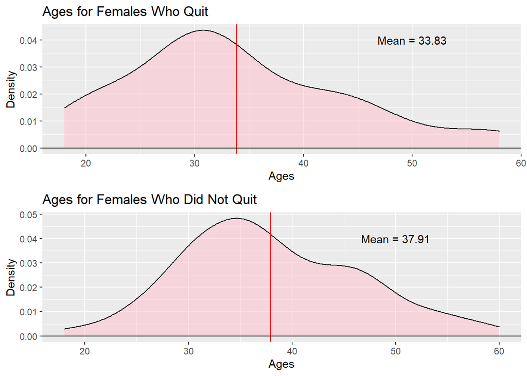

```r
AgeFemAtr <- C2Data %>%
  select(Gender, Age, Attrition) %>%
  filter(Gender == "Female", Attrition =="Yes") %>%
  ggplot(aes(x=Age)) +
  geom_density(alpha = .5, fill='pink') +
  geom_vline(aes(xintercept=mean(Age)), color='red') +
  geom_hline(aes(yintercept=0)) +
  labs(x="Ages",y="Density", title="Ages for Females Who Quit") +
  annotate("text", label = "Mean = 33.83", x=50, y=.04, color = "black")

AgeFemNAtr <- C2Data %>%
  select(Gender, Age, Attrition) %>%
  filter(Gender == "Female", Attrition =="No") %>%
  ggplot(aes(x=Age)) +
  geom_density(alpha = .5, fill='pink') +
  geom_vline(aes(xintercept=mean(Age)), color='red') +
  geom_hline(aes(yintercept=0)) +
  labs(x="Ages",y="Density", title="Ages for Females Who Did Not Quit") +
  annotate("text", label = "Mean = 37.91", x=50, y=.04, color = "black")

#Comparing Female Attrition by Age
plot_grid(AgeFemAtr, AgeFemNAtr, nrow = 2)
```

```r
#Comparing Males and Age Distribution

AgeMalAtr1 <- C2Data %>% # Average Male Age who Quit = 33.76
  select(Gender, Age, Attrition) %>%
  filter (Gender == "Male", Attrition == "Yes")

mean(AgeMalAtr1$Age)
```

```
## [1] 33.75862
```

```r
AgeMalNAtr1 <- C2Data %>% # Average Male Age who Did not Quit = 37.06
  select(Gender, Age, Attrition) %>%
  filter (Gender == "Male", Attrition == "No")

mean(AgeMalNAtr1$Age)
```

```
## [1] 37.05828
```

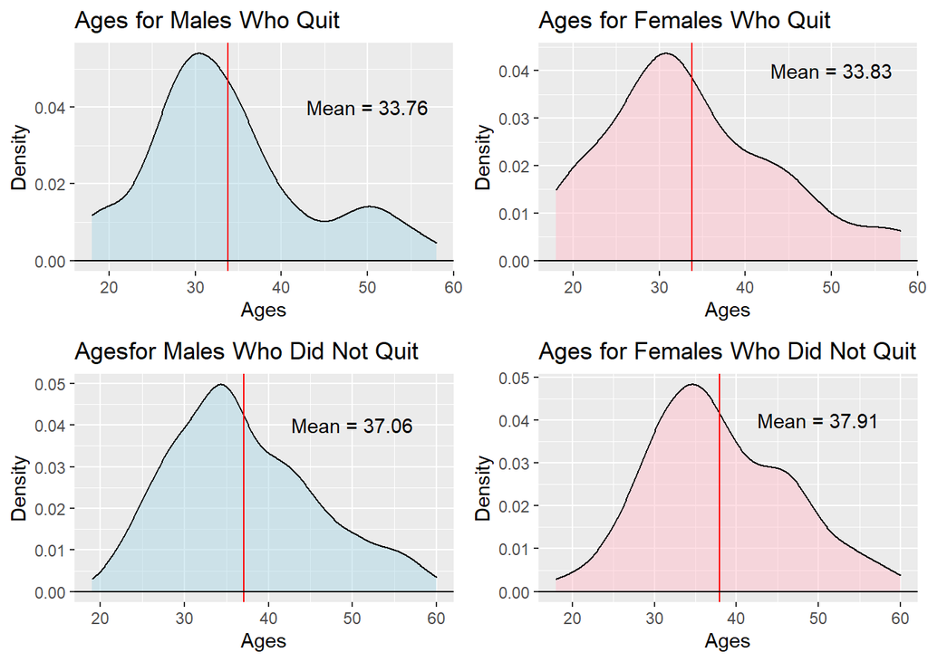

```r
AgeMalAtr <- C2Data %>%
  select(Gender, Age, Attrition) %>%
  filter(Gender == "Male", Attrition =="Yes") %>%
  ggplot(aes(x=Age)) +
  geom_density(alpha = .5, fill='Light Blue') +
  geom_vline(aes(xintercept=mean(Age)), color='red') +
  geom_hline(aes(yintercept=0)) +
  labs(x="Ages",y="Density", title="Ages for Males Who Quit") +
  annotate("text", label = "Mean = 33.76", x=50, y=.04, color = "black")

AgeMalNAtr <- C2Data %>%
  select(Gender, Age, Attrition) %>%
  filter(Gender == "Male", Attrition =="No") %>%
  ggplot(aes(x=Age)) +
  geom_density(alpha = .5, fill='Light Blue') +
  geom_vline(aes(xintercept=mean(Age)), color='red') +
  geom_hline(aes(yintercept=0)) +
  labs(x="Ages",y="Density", title="Agesfor Males Who Did Not Quit") +
  annotate("text", label = "Mean = 37.06", x=50, y=.04, color = "black")

plot_grid(AgeMalAtr, AgeFemAtr, AgeMalNAtr, AgeFemNAtr, nrow = 2)
```

Code Chunk 5: Income Analysis by Gender, department and Jobsatisfaction

```r
AveMalIncAtr <- C2Data %>% # Average income for Males who did not Quit is 6514.94
  select(Gender, Attrition, MonthlyIncome) %>%
  filter (Gender == "Male", Attrition == "No")

mean(AveMalIncAtr$MonthlyIncome)
```

```
## [1] 6514.942
```

```r
AveMalIncNAtr <- C2Data %>% # Average income for Males who Quit is 4530.39
  select(Gender, Attrition, MonthlyIncome) %>%
  filter (Gender == "Male", Attrition == "Yes")

mean(AveMalIncNAtr$MonthlyIncome)
```

```
## [1] 4530.391
```

```r
AveFemIncAtr <- C2Data %>% # Average income for females who did not Quit is 6968.61
  select(Gender, Attrition, MonthlyIncome) %>%
  filter (Gender == "Female", Attrition == "No")

mean(AveFemIncAtr$MonthlyIncome)
```

```
## [1] 6968.605
```

```r
AveFemIncNAtr <- C2Data %>% # Average income for Females who Quit is 5149.55
  select(Gender, Attrition, MonthlyIncome) %>%
  filter (Gender == "Female", Attrition == "Yes")

mean(AveFemIncNAtr$MonthlyIncome)
```

```
## [1] 5149.547
```

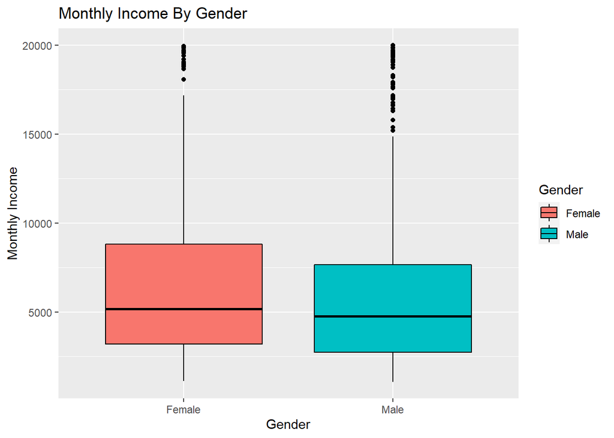

```r
#box plot for income and Gender, to search for gender discrimination
IncGenBox <- C2Data %>%
  select(Gender, Attrition, Department, JobSatisfaction, MonthlyIncome) %>%
  ggplot(aes(x=Gender, y=MonthlyIncome, fill=Gender)) +
  geom_boxplot(color="Black") +
  labs(x="Gender",y="Monthly Income", title="Monthly Income By Gender")

#Income Department and Attrition                                                 !!!!!!!!

IncDeptAtr <- C2Data %>% select(Department, MonthlyIncome, Attrition) %>% group_by(Attrition, Department) %>%
  summarise(IncDeptAtr=mean(MonthlyIncome)) %>%
  ggplot(aes(x=reorder(Department, IncDeptAtr), y=IncDeptAtr, fill=Attrition)) +
  geom_bar(stat="identity", position="dodge") + facet_wrap(~Attrition) +
  labs(y="Average Income", x="Average Monthly Income", title="Average Income by Department and Attrition Status")
#Income Based on Job Satisfaction, not that big of an impact across satisfaction. Suggests pay is more important !!!!!!!!!!!!!!!

IncJobSatAtr <- C2Data %>% select(JobSatisfaction, MonthlyIncome, Attrition) %>% group_by(Attrition, JobSatisfaction) %>%
  summarise(IncJobSatAtr=mean(MonthlyIncome)) %>%
  ggplot(aes(x=JobSatisfaction, y=IncJobSatAtr, fill=Attrition)) +
  geom_bar(stat="identity", position="dodge") + facet_wrap(~Attrition) +
  labs(y="Average Income", x="Job Satisfaction Score", title="Average Income by Job Satisfaction Level and Attrition Status")
#OT per department by attrition                                             !!!!!!!!

oTDeptAtr <- C2Data %>%
  select(Department, Attrition, OverTime) %>%
  ggplot(aes(x=Department, y=OverTime, fill=Attrition)) +
  geom_bar(stat="identity", position="dodge") + facet_wrap(~Attrition) +
  labs(y="Average Income", x="Average Monthly Income", title="Average Income by Department and Attrition Status")

#OTByDepartment
OTDeptAtr  <- C2Data %>%
  select(Department, Attrition, OverTime) %>%
  ggplot(aes(x=Department, fill=OverTime)) +
  geom_bar(stat="count") +
  geom_text(aes(label = ..count..), stat = "count",position = "stack",vjust= 1, size=3) +
  labs(x="Departments",y="Employee Count", title="OT by Department")

IncGenBox
```

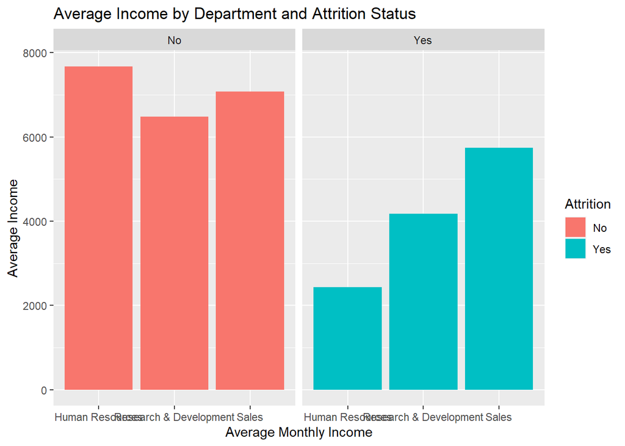

```r
IncDeptAtr
```

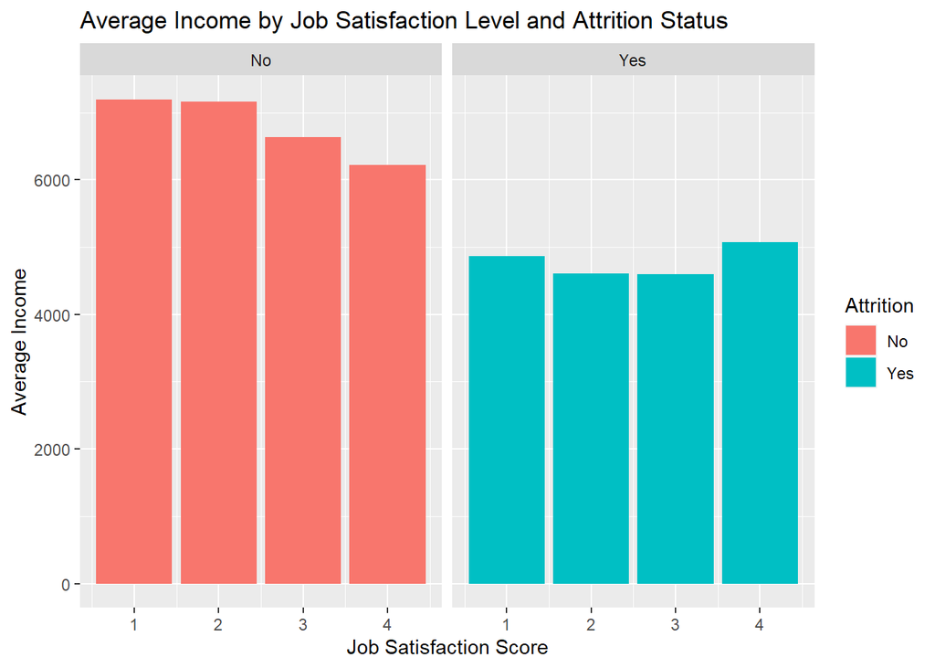

```r
IncJobSatAtr
```

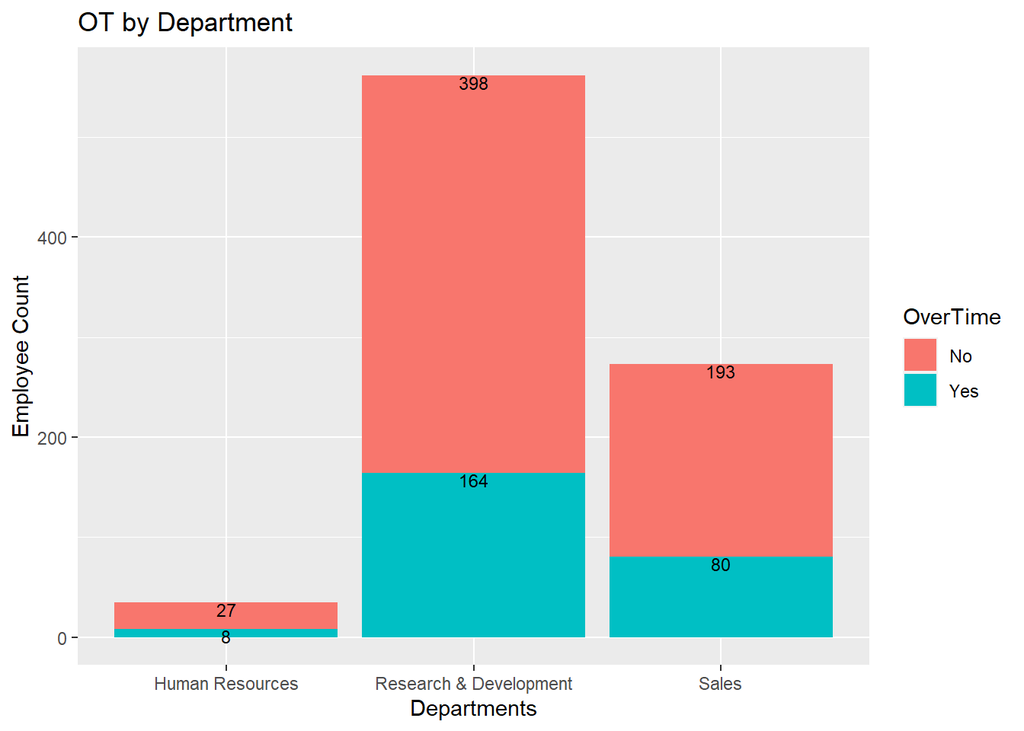

```r
OTDeptAtr
```

Code Chunk 6: There are other factors that impact income that we want to further explore. These include job level, years at the company, years since last promotion, OT. There was a linear relationship between Monthly Income JobLevel, years at the company and years since last promotion. OT there was no linear trend and suggests this may have an impact on attrition. We think OT does play a factor as it can be a signifcant contributor to MonthlyIncome. MonthlyIncome has shown to be an important factors in determining if someone quits or not. We did not use all the charts due to time. Only selected the most meaningful.

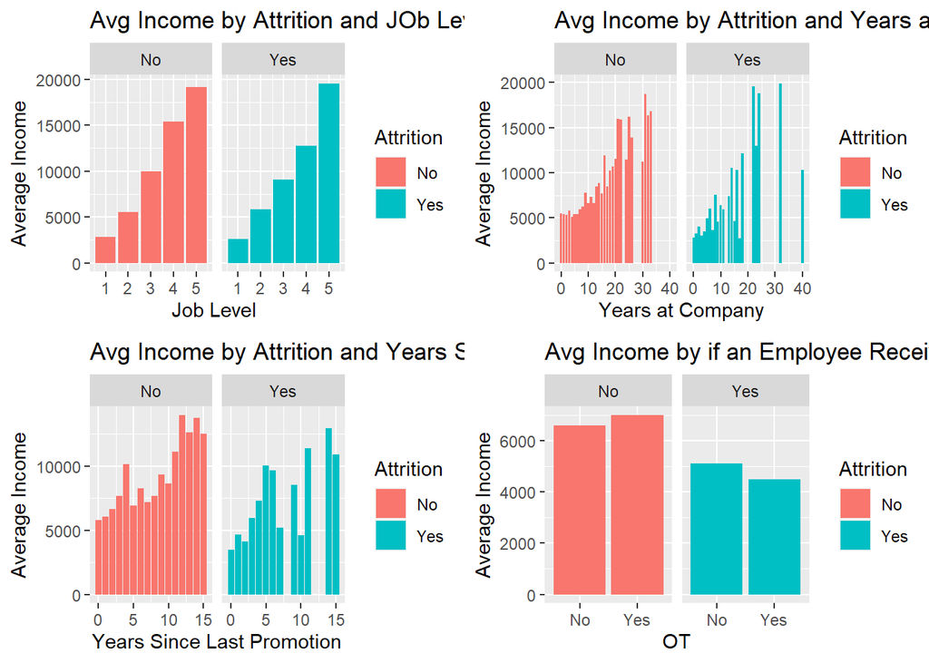

```r
#Job Level, no significant difference, no need to jump into job roles
IncJobLevAtr <- C2Data %>% select(MonthlyIncome, JobLevel, Attrition) %>% group_by(Attrition, JobLevel) %>%
  summarise(IncJobLevAtr =mean(MonthlyIncome)) %>%
  ggplot(aes(x=JobLevel, y=IncJobLevAtr, fill=Attrition)) +
  geom_bar(stat="identity", position="dodge") + facet_wrap(~Attrition) +
  labs(y="Average Income", x="Job Level ", title="Avg Income by Attrition and JOb Level")
#Years at the company (YATC), similar to years since last promotion. Missing data, looks linear with missing datapoints
IncYATCAtr <- C2Data %>% select(MonthlyIncome, YearsAtCompany, Attrition) %>% group_by(Attrition, YearsAtCompany) %>%
  summarise(IncYATCAtr =mean(MonthlyIncome)) %>%
  ggplot(aes(x=YearsAtCompany, y=IncYATCAtr, fill=Attrition)) +
  geom_bar(stat="identity", position="dodge") + facet_wrap(~Attrition) +
  labs(y="Average Income", x="Years at Company", title="Avg Income by Attrition and Years at the Company")
# Years since last promotion, Hard to say but would stat there is a linear relationship, but there are missing data points
#Not as significant but may be impacted by low performance

IncYSLPAtr <- C2Data %>% select(MonthlyIncome, YearsSinceLastPromotion, Attrition) %>% group_by(Attrition, YearsSinceLastPromotion) %>%
  summarise(IncYSLPAtr =mean(MonthlyIncome)) %>%
  ggplot(aes(x=YearsSinceLastPromotion, y=IncYSLPAtr, fill=Attrition)) +
  geom_bar(stat="identity", position="dodge") + facet_wrap(~Attrition) +
  labs(y="Average Income", x="Years Since Last Promotion", title="Avg Income by Attrition and Years Since Last Promoted")
# OT, employees who quit did not get as much OT as employees who stayed                          !!!!!!!!!!!!!!!!
IncOTAtr <- C2Data %>% select(MonthlyIncome, OverTime, Attrition) %>% group_by(Attrition, OverTime) %>%
  summarise(IncOTAtr =mean(MonthlyIncome)) %>%
  ggplot(aes(x=OverTime, y=IncOTAtr, fill=Attrition)) +
  geom_bar(stat="identity", position="dodge") + facet_wrap(~Attrition) +
  labs(y="Average Income", x="OT", title="Avg Income by if an Employee Received OTs")
plot_grid(IncJobLevAtr, IncYATCAtr, IncYSLPAtr, IncOTAtr, nrow = 2)
```

Code Chunk 7: Job Satisfaction Analysis. This was brought about due to the high proportion of attrition in Sales Related jobs. Attrition in sales happens at the same frequency of RD but is half the size. We want to analyze if impacts are from outside or inside the company. Created and commented out the following variables: JobSatHRAtr, JobSatRDNATR, JobSatRDAtr, JobSatRDNAtr, JobSatSalesAtr, JobSatSalesNAtr, JobSatFemATR1, JobSatFemNATR1, JobSatMalART1, JobSatMalNART1. Issues with ggproto objects, only used these to get informatio, were not used to create charts.

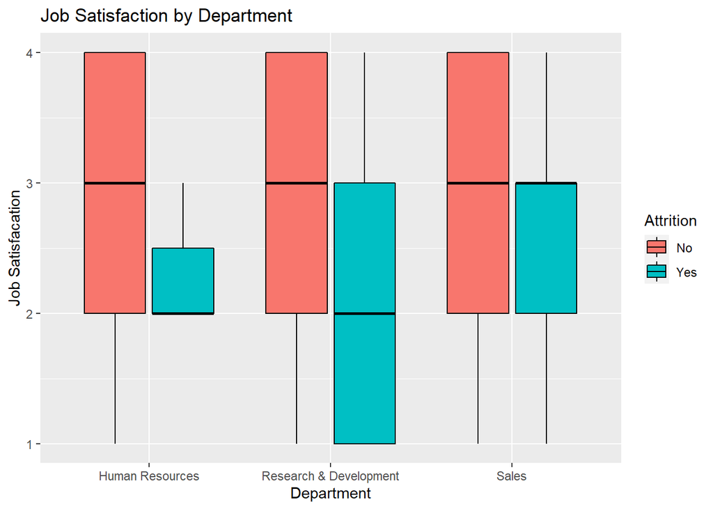

```r
#Overall job satisfaction by Gender, it is about equal between males and females who quit and stayed. Larger Range for
#males who quit but similar averages, doesnt appear to have a strong correlation

#box plot for department and jobsatisfaction
JobSatDept <- C2Data %>%
  select(Gender, Attrition, Department, JobSatisfaction) %>%
  filter(Gender == "Female") %>%
  ggplot(aes(x=Department, y=JobSatisfaction, fill=Attrition)) +
  geom_boxplot(color="Black")+
  labs(x="Department",y="Job Satisfacation", title="Job Satisfaction by Department")

JobSatHRAtr <- C2Data %>% # Average Job Satisfaction for HR who Quit is 2
  select(Department, Gender, Attrition, JobSatisfaction) %>%
  filter (Department == "Human Resources", Attrition == "Yes") %>%
  summarise(JobSatHRAtr=(mean(JobSatisfaction)))

JobSatRDNATR <- C2Data %>% # Average Job Satisfaction for HR who did not Quit is 2.69
  select(Department, Gender, Attrition, JobSatisfaction) %>%
  filter (Department == "Human Resources", Attrition == "No") %>%
  summarise(JobSatRDNATR=(mean(JobSatisfaction)))

JobSatRDAtr <- C2Data %>% # Average Job Satisfaction for RD who Quit is 2.43, Largest Range for attrition of departments
  select(Department, Gender, Attrition, JobSatisfaction) %>%
  filter (Department == "Research & Development", Attrition == "Yes") %>%
  summarise(JobSatRDAtr=(mean(JobSatisfaction)))

JobSatRDNAtr <- C2Data %>% # Average Job Satisfaction for RD who did not Quit is 2.76
 select(Department, Gender, Attrition, JobSatisfaction) %>%
  filter (Department == "Research & Development", Attrition == "No") %>%
  summarise(JobSatRDNAtr=(mean(JobSatisfaction)))

JobSatSalesAtr <- C2Data %>% # Average Job Satisfaction for Sales who Quit is 2.49
  select(Department, Gender, Attrition, JobSatisfaction) %>%
  filter (Department == "Sales", Attrition == "Yes") %>%
  summarise(JobSatSalesAtr=(mean(JobSatisfaction)))

JobSatSalesNAtr <- C2Data %>% # Average Job Satisfaction for Sales who did not Quit is 2.77
  select(Department, Gender, Attrition, JobSatisfaction) %>%
  filter (Department == "Sales", Attrition == "No") %>%
  summarise(JobSatSalesNAtr=(mean(JobSatisfaction)))

#Box plot for gender and jobsatisfaction, No strong correlation

#Job Sat by Gender barchart
JobSatGen <- C2Data %>%
  select(Gender, Attrition, JobSatisfaction) %>%
  ggplot(aes(x=Gender, y=JobSatisfaction, fill=Attrition)) +
  geom_boxplot(color="Black") +
  labs(x="Gender",y="Job Satisfaction", title="Job Satisfaction by Gender")

JobSatFemATR1 <- C2Data %>% # Average Job Satisfaction for Females who Quit is 2.41
  select(Gender, Attrition, JobSatisfaction) %>%
  filter (Gender == "Female", Attrition == "Yes") %>%
  summarise(JobSatFemATR1=mean(JobSatisfaction))

JobSatFemNATR1 <- C2Data %>% # Average Job Satisfaction for Females who did not Quit is 2.73
  select(Gender, Attrition, JobSatisfaction) %>%
  filter (Gender == "Female", Attrition == "No") %>%
  summarise(JobSatFemNATR1=mean(JobSatisfaction))

JobSatMalART1 <- C2Data %>% # Average Job Satisfaction for Males who Quit is 2.45
  select(Gender, Attrition, JobSatisfaction) %>%
  filter (Gender == "Male", Attrition == "Yes") %>%
  summarise(JobSaMalATR1=mean(JobSatisfaction))

JobSatMalNART1 <- C2Data %>% # Average Job Satisfaction for Males who did not Quit is 2.785
  select(Gender, Attrition, JobSatisfaction) %>%
  filter (Gender == "Male", Attrition == "No") %>%
  summarise(JobSaMalATR1=mean(JobSatisfaction))

JobSatTYCMal <- C2Data %>%
  select(Gender, JobSatisfaction, TotalWorkingYears) %>%
  filter(Gender == "Male") %>%
  ggplot(aes(x=TotalWorkingYears)) +
  geom_bar(alpha = .5, fill='Light Blue') +
  labs(x="Ages",y="Density", title="Ages for Males Who Quit") +
  annotate("text", label = "Mean = 33.76", x=50, y=.04, color = "black")

#Job Sat by Total Working Years
JobSatTWY <- C2Data %>%
  select(Gender, JobSatisfaction, TotalWorkingYears, Attrition) %>%
  filter(Attrition =="Yes") %>%
  ggplot(aes(x=TotalWorkingYears, fill="Yes")) +
  geom_bar(stat="count") +
  facet_wrap(~JobSatisfaction) +
  labs(y="Frequency", x="Total Working Years", title="Job Sat for Total Working Years (Male and Female)")

  JobSatDept
```

```r
  JobSatGen
```

[figure not shown]

```r
  JobSatTWY
```

[figure not shown]

Code Chunk 8: Environmental Satisfaction. We did not find any trends but found an interesting data point. We found managers who quit rated their environmental satisfaction under 2. This is the only job role that rates it below 2, this could in turn effect other variables or other job roles satisfaction in relationships, environment or the job itself. Managers play a critical role in maintaining a healthy environment, if they are not happy the chances of them effecting others would be high enough to be concerning. We also checked worklife balance and environmental satisfaction in relation to relationship satisfaction. We did not find anything of concern.

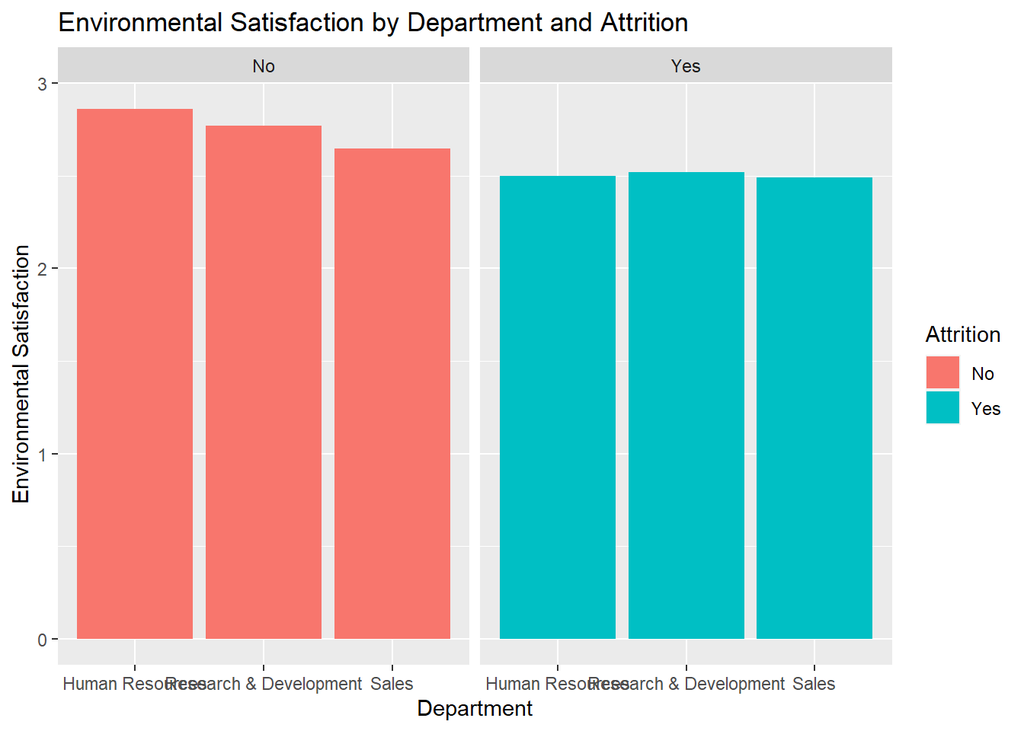

```r
###############
#Environment Satisfaction, last check to evaluate is the environment is causing undo stress on tne employees
###############

#looking at attrition based on environment satisfaction, break down by work life balance, distance from work, relationshipsatisfaction

# Environment Satisfaction by department, No visual difference except in sales, most likely due to stress/nature of the job willl break down by Job Roles
ESDeptAtr <- C2Data %>% select(Department,EnvironmentSatisfaction, Attrition) %>% group_by(Attrition, Department) %>%
  summarise(ESDeptAtr =mean(EnvironmentSatisfaction)) %>%
  ggplot(aes(x=Department, y=ESDeptAtr, fill=Attrition)) +
  geom_bar(stat="identity", position="dodge") + facet_wrap(~Attrition) +
  labs(y="Environmental Satisfaction", x="Department", title="Environmental Satisfaction by Department and Attrition")
#!!!!!!!! Environment Satisfaction by job role, Managers and Research directors had that largest difference in Environmental Satisfaction !!!!!!!!!!!!!!!!!!!!
ESJobRAtr <- C2Data %>% select(JobRole,EnvironmentSatisfaction, Attrition) %>% group_by(Attrition, JobRole) %>%
  summarise(ESJobRAtr  =mean(EnvironmentSatisfaction)) %>%
  ggplot(aes(x=JobRole, y=ESJobRAtr, fill=Attrition)) +
  geom_bar(stat="identity", position="dodge") + facet_wrap(~Attrition) +
  labs(y="Environmental Satisfaction", x="Job Roles", title="Environmental Satisfaction by Job Roles and Attrition") +
  theme(axis.text.x = element_text(angle = 90, hjust = 1, vjust = 0.5))
# Environment Satisfaction by workllife balance, no major significant. Overall rating is below 3.
ESWLBAtr <- C2Data %>% select(WorkLifeBalance,EnvironmentSatisfaction, Attrition) %>% group_by(Attrition, WorkLifeBalance) %>%
  summarise(ESWLBAtr =mean(EnvironmentSatisfaction)) %>%
  ggplot(aes(x=WorkLifeBalance, y=ESWLBAtr, fill=Attrition)) +
  geom_bar(stat="identity", position="dodge") + facet_wrap(~Attrition) +
  labs(y="Environmental Satisfaction", x="Work Life Blance", title="Environmental Satisfaction by Worklife Balance and Attrition")
# Environment Satisfaction by relationship satisfaction. Relatively insignificant difference between Ones who quit and did not. Who quit
# were expected to have sifgnicantly lower environmental satisfaction, they did not. They were realatively even.
ESRSAtr <- C2Data %>% select(RelationshipSatisfaction, EnvironmentSatisfaction, Attrition) %>% group_by(Attrition,RelationshipSatisfaction) %>%
  summarise(ESRSAtr =mean(EnvironmentSatisfaction)) %>%
  ggplot(aes(x=RelationshipSatisfaction, y=ESRSAtr, fill=Attrition)) +
  geom_bar(stat="identity", position="dodge") + facet_wrap(~Attrition) +
  labs(y="Environmental Satisfaction", x="RelationshipSatisfaction", title="Environmental Satisfaction by Relationship Satisfaction and Attrition")
#plot_grid(ESDeptAtr, ESJobRAtr, ESWLBAtr, ESRSAtr, nrow=2)

ESDeptAtr
```

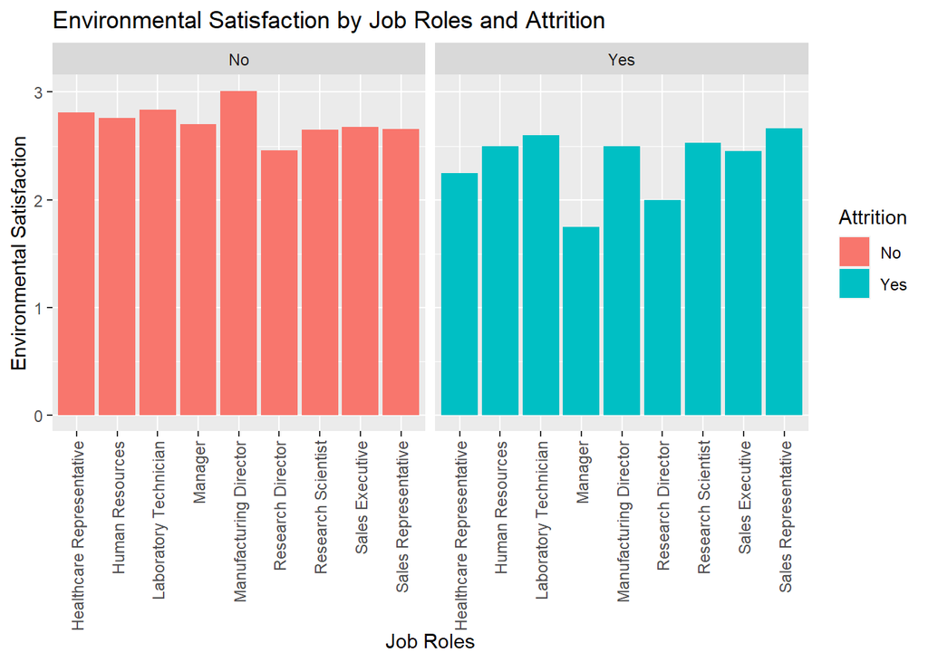

```r
ESJobRAtr
```

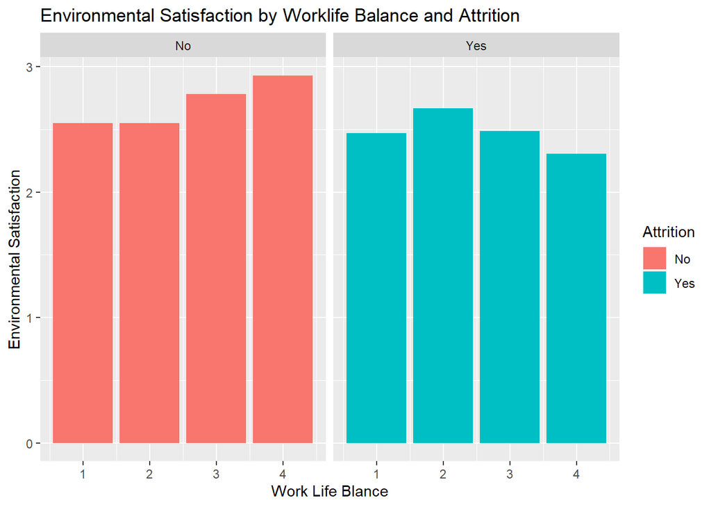

```r
ESWLBAtr
```

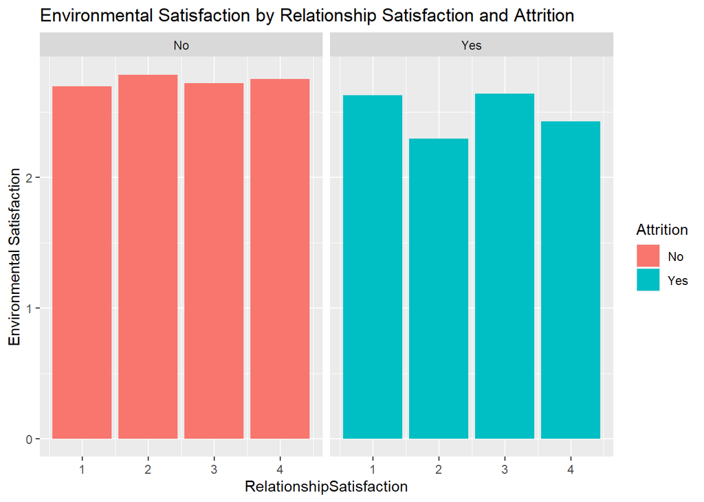

```r
ESRSAtr
```

Code Chunk 8a: xpanded Environmental check into Jobroles

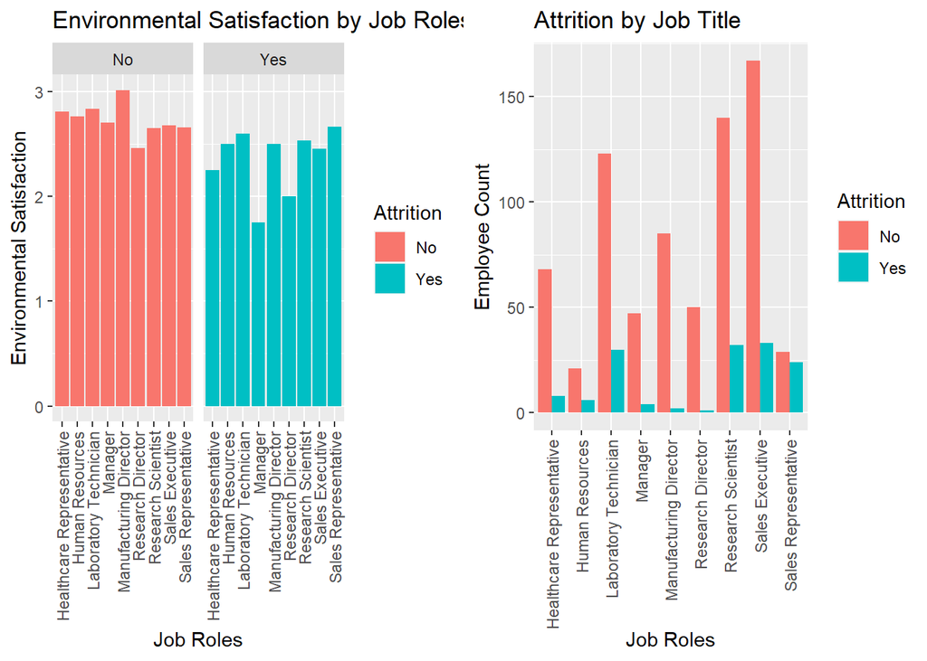

```r
ArtJobRole<- C2Data %>%
  select(JobRole, Attrition) %>%
  ggplot(aes(x=JobRole, fill=Attrition))+
  geom_bar(position="dodge",stat="count") +
  labs(x="Job Roles",y="Employee Count", title="Attrition by Job Title")+
  theme(axis.text.x = element_text(angle = 90, hjust = 1, vjust = 0.5))

plot_grid(ESJobRAtr, ArtJobRole, nrow=1)
```

Code Chunk 9: Correlation matrix. We created a correlation matrix to verify which variables are correlated and would help build a useful model. We were able to identify Age, TotalWorkingYears, JobLevel as the top 3 variables that would best predict/estimate salary for an associate.

```r
#From our initial analysis we have selected Age, Income (Overall), OT (As a contributor to Income difference). We will create a correlation matrix to verify relationships
#Not as significant points of interest. We have observed differences in manager satisfaction with their job/environment. This job role has had several

#Correlation plot with corrplot to refine our our EDA


#convert CHARs to INT

C2Drops <- c("EmployeeCount","StandardHours", "Over18")
C2Data1 <- C2Data[,!(names(C2Data) %in% C2Drops)]

C2Data1$Attrition = as.numeric(C2Data1$Attrition)
C2Data1$BusinessTravel = as.numeric(C2Data1$BusinessTravel)
C2Data1$Department = as.numeric(C2Data1$Department)
C2Data1$EducationField = as.numeric(C2Data1$EducationField)
C2Data1$Gender = as.numeric(C2Data1$Gender)
C2Data1$JobRole = as.numeric(C2Data1$JobRole)
C2Data1$MaritalStatus = as.numeric(C2Data1$MaritalStatus)
C2Data1$OverTime = as.numeric(C2Data1$OverTime)


corrC2Data = rcorr(as.matrix(C2Data1))

corrc2Data1 = cor(C2Data1, method = "pearson")
corrc2Data1
```

```
##                                    ID          Age    Attrition BusinessTravel
## ID                        1.000000000 -0.040097596  0.047266995  -0.0150183236
## Age                      -0.040097596  1.000000000 -0.149383577   0.0016688158
## Attrition                 0.047266995 -0.149383577  1.000000000  -0.0061255976
## BusinessTravel           -0.015018324  0.001668816 -0.006125598   1.0000000000
## DailyRate                -0.032902279  0.012736692 -0.033793125  -0.0189458993
## Department               -0.058769950 -0.045415060  0.087031988  -0.0365691634
## DistanceFromHome          0.066138779  0.006647112  0.087136293  -0.0627526960
## Education                -0.049538273  0.217290207 -0.049442357   0.0146522333
## EducationField            0.076693640 -0.062474673  0.026142151  -0.0194350502
## EmployeeNumber           -0.022352503  0.010470589 -0.022793834   0.0191456876
## EnvironmentSatisfaction  -0.012725264 -0.007449882 -0.077325405  -0.0006234879
## Gender                   -0.003111656 -0.044228011  0.025250336  -0.0061915674
## HourlyRate                0.006259530  0.052328259  0.036554178   0.0052800228
## JobInvolvement           -0.050285102  0.016073296 -0.187793409   0.0415380567
## JobLevel                 -0.039260585  0.479423564 -0.162136444   0.0305123304
## JobRole                  -0.069017184 -0.105969885  0.090538602  -0.0242854727
## JobSatisfaction           0.040917532 -0.022363414 -0.107520935  -0.0422218775
## MaritalStatus             0.045684938 -0.103143421  0.197014951   0.0236472641
## MonthlyIncome            -0.051639025  0.484288301 -0.154914955   0.0627069040
## MonthlyRate              -0.004748305  0.071740854 -0.043232173   0.0098597069
## NumCompaniesWorked       -0.018549395  0.293521877  0.061018887  -0.0177485879
## OverTime                  0.021248854  0.001749380  0.272036591   0.0308609341
## PercentSalaryHike         0.017039305 -0.030804192  0.015328069  -0.0133508505
## PerformanceRating         0.016405803 -0.041084685  0.015333837  -0.0118828003
## RelationshipSatisfaction -0.041604748 -0.005340777 -0.039646611  -0.0470025207
## StockOptionLevel         -0.004297641  0.044759576 -0.148680303  -0.0114569593
## TotalWorkingYears        -0.042010558  0.652613137 -0.167206122   0.0338545407
## TrainingTimesLastYear     0.030408578 -0.045281792 -0.062726088   0.0039301879
## WorkLifeBalance           0.010458196 -0.012229885 -0.089789709  -0.0252787832
## YearsAtCompany            0.006726733  0.289538716 -0.128754060  -0.0020159832
## YearsInCurrentRole       -0.068856386  0.208349696 -0.156215707   0.0153517539
## YearsSinceLastPromotion   0.003515130  0.217191680 -0.004573321  -0.0446767042
## YearsWithCurrManager     -0.038176461  0.185383795 -0.146782245  -0.0297825484
##                              DailyRate    Department DistanceFromHome
## ID                       -3.290228e-02 -5.876995e-02      0.066138779
## Age                       1.273669e-02 -4.541506e-02      0.006647112
## Attrition                -3.379312e-02  8.703199e-02      0.087136293
## BusinessTravel           -1.894590e-02 -3.656916e-02     -0.062752696
## DailyRate                 1.000000e+00  1.735821e-02      0.014944536
```

[output cut: 353 more lines]

```
## MonthlyIncome                        0.315911576          0.328487453
## MonthlyRate                          0.007491151         -0.021310286
## NumCompaniesWorked                  -0.071218393         -0.122974681
## OverTime                            -0.015582037         -0.047055347
## PercentSalaryHike                   -0.074040285         -0.045232326
## PerformanceRating                   -0.036530370         -0.004942028
## RelationshipSatisfaction             0.032135460         -0.016131001
## StockOptionLevel                     0.012955322          0.036542574
## TotalWorkingYears                    0.445838540          0.461485375
## TrainingTimesLastYear               -0.042382617          0.003914247
## WorkLifeBalance                      0.041653100          0.018378039
## YearsAtCompany                       0.644029778          0.765226243
## YearsInCurrentRole                   0.553710048          0.709461217
## YearsSinceLastPromotion              1.000000000          0.508935431
## YearsWithCurrManager                 0.508935431          1.000000000
```